# Example: Diabetes

```r
library(multinma)
options(mc.cores = parallel::detectCores())
```

This vignette describes the analysis of data on the number of new cases of diabetes in 22 trials of 6 antihypertensive drugs (Elliott and Meyer 2007; Dias et al. 2011). The data are available in this package as `diabetes`:

```r
head(diabetes)
```

```
#>   studyn studyc trtn         trtc   r    n time
#> 1      1  MRC-E    1     Diuretic  43 1081  5.8
#> 2      1  MRC-E    2      Placebo  34 2213  5.8
#> 3      1  MRC-E    3 Beta Blocker  37 1102  5.8
#> 4      2   EWPH    1     Diuretic  29  416  4.7
#> 5      2   EWPH    2      Placebo  20  424  4.7
#> 6      3   SHEP    1     Diuretic 140 1631  3.0
```

## Setting up the network

We begin by setting up the network. We have arm-level count data giving the number of new cases of diabetes (`r`) out of the total (`n`) in each arm, so we use the function `set_agd_arm()`. For computational efficiency, we let “Beta Blocker” be set as the network reference treatment by default. Elliott and Meyer (2007) and Dias et al. (2011) use “Diuretic” as the reference, but it is a simple matter to transform the results after fitting the NMA model.[^1]

```r
db_net <- set_agd_arm(diabetes,
                      study = studyc,
                      trt = trtc,
                      r = r,
                      n = n)
db_net
```

```
#> A network with 22 AgD studies (arm-based).
#>
#> ------------------------------------------------------- AgD studies (arm-based) ----
#>  Study  Treatment arms
#>  AASK   3: Beta Blocker | ACE Inhibitor | CCB
#>  ALLHAT 3: ACE Inhibitor | CCB | Diuretic
#>  ALPINE 2: ARB | Diuretic
#>  ANBP-2 2: ACE Inhibitor | Diuretic
#>  ASCOT  2: Beta Blocker | CCB
#>  CAPPP  2: Beta Blocker | ACE Inhibitor
#>  CHARM  2: ARB | Placebo
#>  DREAM  2: ACE Inhibitor | Placebo
#>  EWPH   2: Diuretic | Placebo
#>  FEVER  2: CCB | Placebo
#>  ... plus 12 more studies
#>
#>  Outcome type: count
#> ------------------------------------------------------------------------------------
#> Total number of treatments: 6
#> Total number of studies: 22
#> Reference treatment is: Beta Blocker
#> Network is connected
```

We also have details of length of follow-up in years in each trial (`time`), which we will use as an offset with a cloglog link function to model the data as rates. We do not have to specify this in the function `set_agd_arm()`: any additional columns in the data (e.g. offsets or covariates, here the column `time`) will automatically be made available in the network.

Plot the network structure.

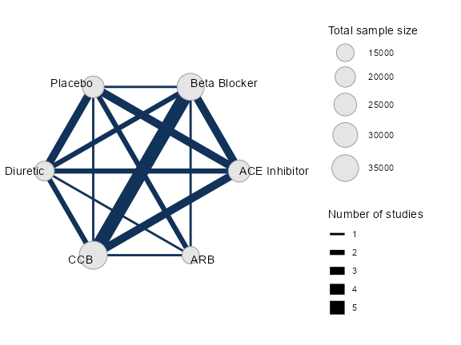

```r
plot(db_net, weight_edges = TRUE, weight_nodes = TRUE)
```

## Meta-analysis models

We fit both fixed effect (FE) and random effects (RE) models.

### Fixed effect meta-analysis

First, we fit a fixed effect model using the `nma()` function with `trt_effects = "fixed"`. We use $\mathrm{N}(0, 100^2)$ prior distributions for the treatment effects $d_k$ and study-specific intercepts $\mu_j$. We can examine the range of parameter values implied by these prior distributions with the `summary()` method:

```r
summary(normal(scale = 100))
```

```
#> A Normal prior distribution: location = 0, scale = 100.
#> 50% of the prior density lies between -67.45 and 67.45.
#> 95% of the prior density lies between -196 and 196.
```

The model is fitted using the `nma()` function. We specify that a cloglog link will be used with `link = "cloglog"` (the Binomial likelihood is the default for these data), and specify the log follow-up time offset using the regression formula `regression = ~offset(log(time))`.

```r
db_fit_FE <- nma(db_net,
                 trt_effects = "fixed",
                 link = "cloglog",
                 regression = ~offset(log(time)),
                 prior_intercept = normal(scale = 100),
                 prior_trt = normal(scale = 100))
```

```
#> Note: No treatment classes specified in network, any interactions in `regression` formula will be separate (independent) for each treatment.
#> Use set_*() argument `trt_class` and nma() argument `class_interactions` to change this.
#> Note: Setting "Beta Blocker" as the network reference treatment.
```

Basic parameter summaries are given by the `print()` method:

```r
db_fit_FE
```

```
#> A fixed effects NMA with a binomial likelihood (cloglog link).
#> Regression model: ~offset(log(time)).
#> Inference for Stan model: binomial_1par.
#> 4 chains, each with iter=2000; warmup=1000; thin=1;
#> post-warmup draws per chain=1000, total post-warmup draws=4000.
#>
#>                       mean se_mean   sd      2.5%       25%       50%       75%     97.5% n_eff
#> d[ACE Inhibitor]     -0.30    0.00 0.05     -0.39     -0.33     -0.30     -0.27     -0.21  1441
#> d[ARB]               -0.39    0.00 0.05     -0.48     -0.43     -0.39     -0.36     -0.31  2116
#> d[CCB]               -0.20    0.00 0.03     -0.26     -0.22     -0.20     -0.17     -0.13  1884
#> d[Diuretic]           0.06    0.00 0.06     -0.05      0.02      0.06      0.10      0.17  1791
#> d[Placebo]           -0.19    0.00 0.05     -0.29     -0.22     -0.19     -0.16     -0.09  1429
#> lp__             -37970.32    0.09 3.58 -37978.17 -37972.59 -37969.93 -37967.70 -37964.34  1538
#>                  Rhat
#> d[ACE Inhibitor]    1
#> d[ARB]              1
#> d[CCB]              1
#> d[Diuretic]         1
#> d[Placebo]          1
#> lp__                1
#>
#> Samples were drawn using NUTS(diag_e) at Mon Apr 29 16:39:01 2024.
#> For each parameter, n_eff is a crude measure of effective sample size,
#> and Rhat is the potential scale reduction factor on split chains (at
#> convergence, Rhat=1).
```

By default, summaries of the study-specific intercepts $\mu_j$ are hidden, but could be examined by changing the `pars` argument:

```r
# Not run
print(db_fit_FE, pars = c("d", "mu"))
```

The prior and posterior distributions can be compared visually using the `plot_prior_posterior()` function:

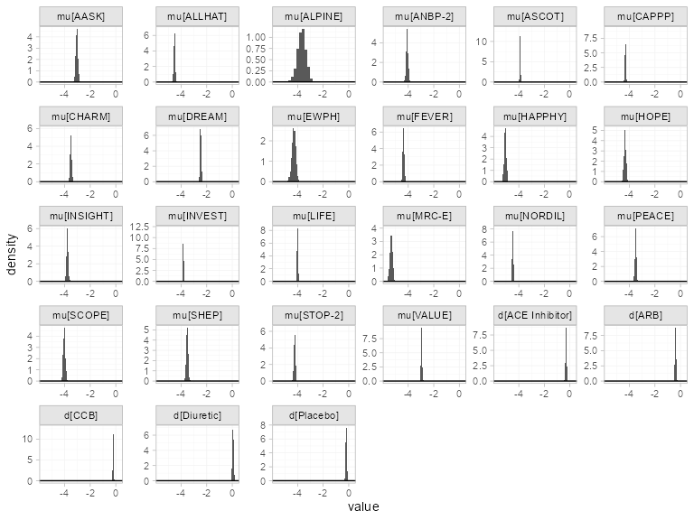

```r
plot_prior_posterior(db_fit_FE)
```

### Random effects meta-analysis

```r
summary(normal(scale = 100))
```

```
#> A Normal prior distribution: location = 0, scale = 100.
#> 50% of the prior density lies between -67.45 and 67.45.
#> 95% of the prior density lies between -196 and 196.
```

```r
summary(half_normal(scale = 5))
```

```
#> A half-Normal prior distribution: location = 0, scale = 5.
#> 50% of the prior density lies between 0 and 3.37.
#> 95% of the prior density lies between 0 and 9.8.
```

Fitting the RE model

```r
db_fit_RE <- nma(db_net,
                 trt_effects = "random",
                 link = "cloglog",
                 regression = ~offset(log(time)),
                 prior_intercept = normal(scale = 10),
                 prior_trt = normal(scale = 10),
                 prior_het = half_normal(scale = 5),
                 init_r = 0.5)
```

```
#> Note: No treatment classes specified in network, any interactions in `regression` formula will be separate (independent) for each treatment.
#> Use set_*() argument `trt_class` and nma() argument `class_interactions` to change this.
#> Note: Setting "Beta Blocker" as the network reference treatment.
```

Basic parameter summaries are given by the `print()` method:

```r
db_fit_RE
```

```
#> A random effects NMA with a binomial likelihood (cloglog link).
#> Regression model: ~offset(log(time)).
#> Inference for Stan model: binomial_1par.
#> 4 chains, each with iter=2000; warmup=1000; thin=1;
#> post-warmup draws per chain=1000, total post-warmup draws=4000.
#>
#>                       mean se_mean   sd      2.5%       25%       50%       75%     97.5% n_eff
#> d[ACE Inhibitor]     -0.33    0.00 0.08     -0.49     -0.38     -0.33     -0.28     -0.18  2166
#> d[ARB]               -0.40    0.00 0.10     -0.59     -0.46     -0.40     -0.34     -0.22  2355
#> d[CCB]               -0.17    0.00 0.07     -0.30     -0.21     -0.17     -0.13     -0.04  2131
#> d[Diuretic]           0.07    0.00 0.09     -0.10      0.02      0.07      0.13      0.25  2205
#> d[Placebo]           -0.22    0.00 0.09     -0.40     -0.27     -0.21     -0.16     -0.05  1782
#> lp__             -37981.26    0.24 6.96 -37996.03 -37985.56 -37980.85 -37976.46 -37968.78   845
#> tau                   0.13    0.00 0.04      0.05      0.10      0.12      0.15      0.23   924
#>                  Rhat
#> d[ACE Inhibitor]    1
#> d[ARB]              1
#> d[CCB]              1
#> d[Diuretic]         1
#> d[Placebo]          1
#> lp__                1
#> tau                 1
#>
#> Samples were drawn using NUTS(diag_e) at Mon Apr 29 16:39:24 2024.
#> For each parameter, n_eff is a crude measure of effective sample size,
#> and Rhat is the potential scale reduction factor on split chains (at
#> convergence, Rhat=1).
```

By default, summaries of the study-specific intercepts $\mu_j$ and study-specific relative effects $\delta_{jk}$ are hidden, but could be examined by changing the `pars` argument:

```r
# Not run
print(db_fit_RE, pars = c("d", "mu", "delta"))
```

The prior and posterior distributions can be compared visually using the `plot_prior_posterior()` function:

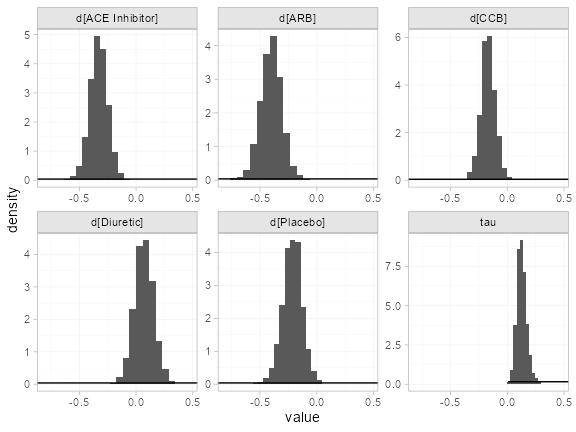

```r
plot_prior_posterior(db_fit_RE, prior = c("trt", "het"))
```

### Model comparison

Model fit can be checked using the `dic()` function:

```r
(dic_FE <- dic(db_fit_FE))
```

```
#> Residual deviance: 78.2 (on 48 data points)
#>                pD: 27
#>               DIC: 105.3
```

```r
(dic_RE <- dic(db_fit_RE))
```

```
#> Residual deviance: 54 (on 48 data points)
#>                pD: 38.3
#>               DIC: 92.3
```

The FE model is a very poor fit to the data, with a residual deviance much higher than the number of data points. The RE model fits the data better, and has a much lower DIC; we prefer the RE model.

We can also examine the residual deviance contributions with the corresponding `plot()` method.

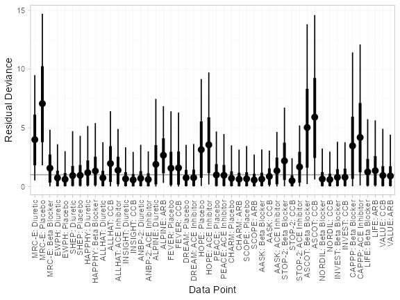

```r
plot(dic_FE)
```

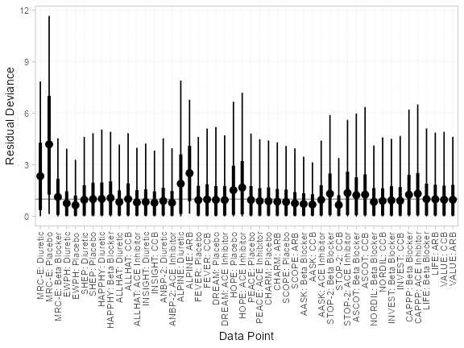

```r
plot(dic_RE)
```

## Further results

For comparison with Elliott and Meyer (2007) and Dias et al. (2011), we can produce relative effects against “Diuretic” using the `relative_effects()` function with `trt_ref = "Diuretic"`:

```r
(db_releff_FE <- relative_effects(db_fit_FE, trt_ref = "Diuretic"))
```

```
#>                   mean   sd  2.5%   25%   50%   75% 97.5% Bulk_ESS Tail_ESS Rhat
#> d[Beta Blocker]  -0.06 0.06 -0.17 -0.10 -0.06 -0.02  0.05     1801     2541    1
#> d[ACE Inhibitor] -0.36 0.05 -0.46 -0.39 -0.36 -0.32 -0.25     4373     3227    1
#> d[ARB]           -0.45 0.06 -0.57 -0.49 -0.45 -0.41 -0.33     3366     3057    1
#> d[CCB]           -0.25 0.05 -0.36 -0.29 -0.25 -0.21 -0.15     2922     2896    1
#> d[Placebo]       -0.25 0.06 -0.36 -0.28 -0.25 -0.21 -0.13     4119     3051    1
```

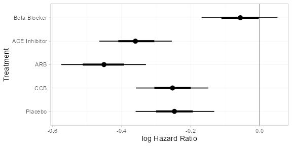

```r
plot(db_releff_FE, ref_line = 0)
```

```r
(db_releff_RE <- relative_effects(db_fit_RE, trt_ref = "Diuretic"))
```

```
#>                   mean   sd  2.5%   25%   50%   75% 97.5% Bulk_ESS Tail_ESS Rhat
#> d[Beta Blocker]  -0.07 0.09 -0.25 -0.13 -0.07 -0.02  0.10     2263     2536    1
#> d[ACE Inhibitor] -0.40 0.09 -0.58 -0.46 -0.40 -0.34 -0.24     4739     2870    1
#> d[ARB]           -0.47 0.11 -0.71 -0.54 -0.47 -0.40 -0.26     4152     2646    1
#> d[CCB]           -0.24 0.08 -0.41 -0.29 -0.24 -0.19 -0.08     5016     3221    1
#> d[Placebo]       -0.29 0.09 -0.47 -0.34 -0.29 -0.23 -0.12     4421     3111    1
```

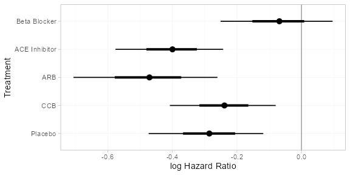

```r
plot(db_releff_RE, ref_line = 0)
```

Dias et al. (2011) produce absolute predictions of the probability of developing diabetes after three years, assuming a Normal distribution on the baseline cloglog probability of developing diabetes on diuretic treatment with mean $-4.2$ and precision $1.11$. We can replicate these results using the `predict()` method. We specify a data frame of `newdata`, containing the `time` offset(s) at which to produce predictions (here only 3 years). The `baseline` argument takes a `distr()` distribution object with which we specify the corresponding Normal distribution on the baseline cloglog probability, and we set `baseline_trt = "Diuretic"` to indicate that the baseline distribution corresponds to “Diuretic” rather than the network reference “Beta Blocker”. We set `type = "response"` to produce predicted event probabilities (`type = "link"` would produce predicted cloglog probabilities).

```r
db_pred_FE <- predict(db_fit_FE,
                      newdata = data.frame(time = 3),
                      baseline = distr(qnorm, mean = -4.2, sd = 1.11^-0.5),
                      baseline_trt = "Diuretic",
                      type = "response")
db_pred_FE
```

```
#> ------------------------------------------------------------------ Study: New 1 ----
#>
#>                            mean   sd 2.5%  25%  50%  75% 97.5% Bulk_ESS Tail_ESS Rhat
#> pred[New 1: Beta Blocker]  0.06 0.07 0.01 0.02 0.04 0.08  0.24     3758     3959    1
#> pred[New 1: ACE Inhibitor] 0.05 0.05 0.01 0.02 0.03 0.06  0.19     3755     4098    1
#> pred[New 1: ARB]           0.04 0.05 0.00 0.02 0.03 0.05  0.17     3767     4097    1
#> pred[New 1: CCB]           0.05 0.06 0.01 0.02 0.03 0.06  0.20     3760     4046    1
#> pred[New 1: Diuretic]      0.07 0.07 0.01 0.02 0.04 0.08  0.26     3755     3924    1
#> pred[New 1: Placebo]       0.05 0.06 0.01 0.02 0.03 0.06  0.21     3767     3917    1
```

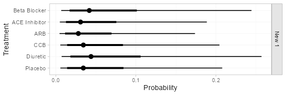

```r
plot(db_pred_FE)
```

```r
db_pred_RE <- predict(db_fit_RE,
                      newdata = data.frame(time = 3),
                      baseline = distr(qnorm, mean = -4.2, sd = 1.11^-0.5),
                      baseline_trt = "Diuretic",
                      type = "response")
db_pred_RE
```

```
#> ------------------------------------------------------------------ Study: New 1 ----
#>
#>                            mean   sd 2.5%  25%  50%  75% 97.5% Bulk_ESS Tail_ESS Rhat
#> pred[New 1: Beta Blocker]  0.06 0.06 0.01 0.02 0.04 0.07  0.24     3991     3930    1
#> pred[New 1: ACE Inhibitor] 0.04 0.05 0.00 0.02 0.03 0.05  0.18     4017     4015    1
#> pred[New 1: ARB]           0.04 0.05 0.00 0.01 0.03 0.05  0.16     4001     3932    1
#> pred[New 1: CCB]           0.05 0.06 0.01 0.02 0.03 0.06  0.20     4049     3974    1
#> pred[New 1: Diuretic]      0.06 0.07 0.01 0.02 0.04 0.08  0.25     3989     3892    1
#> pred[New 1: Placebo]       0.05 0.05 0.01 0.02 0.03 0.06  0.19     4002     4015    1
```

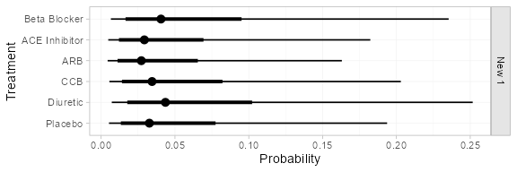

```r
plot(db_pred_RE)
```

If the `baseline` and `newdata` arguments are omitted, predicted probabilities will be produced for every study in the network based on their follow-up times and estimated baseline cloglog probabilities $\mu_j$:

```r
db_pred_RE_studies <- predict(db_fit_RE, type = "response")
db_pred_RE_studies
```

```
#> ------------------------------------------------------------------- Study: AASK ----
#>
#>                           mean   sd 2.5%  25%  50%  75% 97.5% Bulk_ESS Tail_ESS Rhat
#> pred[AASK: Beta Blocker]  0.17 0.02 0.14 0.16 0.17 0.18  0.20     5589     2823    1
#> pred[AASK: ACE Inhibitor] 0.12 0.01 0.10 0.12 0.12 0.13  0.15     4599     2711    1
#> pred[AASK: ARB]           0.12 0.01 0.09 0.11 0.12 0.13  0.15     4401     2946    1
#> pred[AASK: CCB]           0.14 0.01 0.12 0.13 0.14 0.15  0.18     5196     2850    1
#> pred[AASK: Diuretic]      0.18 0.02 0.14 0.17 0.18 0.19  0.22     4210     2956    1
#> pred[AASK: Placebo]       0.14 0.02 0.11 0.13 0.14 0.15  0.17     3677     2770    1
#>
#> ----------------------------------------------------------------- Study: ALLHAT ----
#>
#>                             mean   sd 2.5%  25%  50%  75% 97.5% Bulk_ESS Tail_ESS Rhat
#> pred[ALLHAT: Beta Blocker]  0.04 0.01 0.03 0.04 0.04 0.05  0.06     2678     2340    1
#> pred[ALLHAT: ACE Inhibitor] 0.03 0.00 0.02 0.03 0.03 0.03  0.04     4297     2350    1
#> pred[ALLHAT: ARB]           0.03 0.00 0.02 0.03 0.03 0.03  0.04     3918     2452    1
#> pred[ALLHAT: CCB]           0.04 0.00 0.03 0.03 0.04 0.04  0.05     4199     2190    1
#> pred[ALLHAT: Diuretic]      0.05 0.01 0.04 0.04 0.05 0.05  0.06     4544     2710    1
#> pred[ALLHAT: Placebo]       0.03 0.00 0.03 0.03 0.03 0.04  0.04     3729     2838    1
#>
#> ----------------------------------------------------------------- Study: ALPINE ----
#>
#>                             mean   sd 2.5%  25%  50%  75% 97.5% Bulk_ESS Tail_ESS Rhat
#> pred[ALPINE: Beta Blocker]  0.03 0.01 0.01 0.02 0.03 0.03  0.05     6749     3136    1
#> pred[ALPINE: ACE Inhibitor] 0.02 0.01 0.01 0.01 0.02 0.02  0.04     7455     3173    1
#> pred[ALPINE: ARB]           0.02 0.01 0.01 0.01 0.02 0.02  0.03     7520     3382    1
#> pred[ALPINE: CCB]           0.02 0.01 0.01 0.02 0.02 0.03  0.04     7470     3346    1
#> pred[ALPINE: Diuretic]      0.03 0.01 0.01 0.02 0.03 0.03  0.05     7744     3343    1
#> pred[ALPINE: Placebo]       0.02 0.01 0.01 0.02 0.02 0.03  0.04     7705     3296    1
#>
#> ----------------------------------------------------------------- Study: ANBP-2 ----
#>
#>                             mean   sd 2.5%  25%  50%  75% 97.5% Bulk_ESS Tail_ESS Rhat
#> pred[ANBP-2: Beta Blocker]  0.07 0.01 0.05 0.06 0.07 0.07  0.09     3624     2292    1
#> pred[ANBP-2: ACE Inhibitor] 0.05 0.01 0.04 0.04 0.05 0.05  0.06     5435     2763    1
#> pred[ANBP-2: ARB]           0.05 0.01 0.03 0.04 0.05 0.05  0.06     5110     2884    1
#> pred[ANBP-2: CCB]           0.06 0.01 0.04 0.05 0.06 0.06  0.08     5140     3016    1
#> pred[ANBP-2: Diuretic]      0.07 0.01 0.06 0.07 0.07 0.08  0.09     5670     2938    1
#> pred[ANBP-2: Placebo]       0.05 0.01 0.04 0.05 0.05 0.06  0.07     5632     3088    1
#>
```

[output cut: 164 more lines]

```
#> pred[STOP-2: ACE Inhibitor] 0.04 0.00 0.03 0.04 0.04 0.04  0.05     3230     3131    1
#> pred[STOP-2: ARB]           0.04 0.00 0.03 0.03 0.04 0.04  0.05     3260     2961    1
#> pred[STOP-2: CCB]           0.05 0.00 0.04 0.04 0.05 0.05  0.05     4151     2922    1
#> pred[STOP-2: Diuretic]      0.06 0.01 0.05 0.05 0.06 0.06  0.07     3857     3132    1
#> pred[STOP-2: Placebo]       0.04 0.00 0.03 0.04 0.04 0.05  0.05     2904     2851    1
#>
#> ------------------------------------------------------------------ Study: VALUE ----
#>
#>                            mean   sd 2.5%  25%  50%  75% 97.5% Bulk_ESS Tail_ESS Rhat
#> pred[VALUE: Beta Blocker]  0.20 0.02 0.15 0.18 0.19 0.21  0.25     3053     2187    1
#> pred[VALUE: ACE Inhibitor] 0.15 0.02 0.11 0.13 0.14 0.16  0.19     4654     2519    1
#> pred[VALUE: ARB]           0.14 0.02 0.10 0.13 0.14 0.14  0.17     4783     2673    1
#> pred[VALUE: CCB]           0.17 0.02 0.13 0.16 0.17 0.18  0.21     4538     2131    1
#> pred[VALUE: Diuretic]      0.21 0.03 0.16 0.19 0.21 0.22  0.27     4774     2679    1
#> pred[VALUE: Placebo]       0.16 0.02 0.12 0.15 0.16 0.17  0.21     4816     2530    1
```

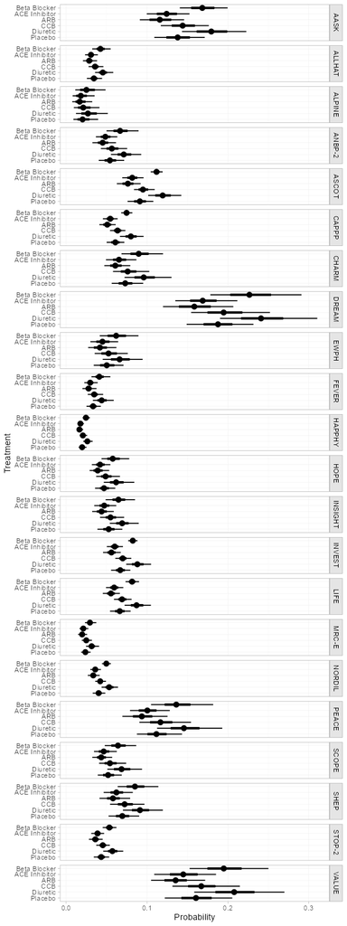

```r
plot(db_pred_RE_studies)
```

We can also produce treatment rankings, rank probabilities, and cumulative rank probabilities.

```r
(db_ranks <- posterior_ranks(db_fit_RE))
```

```
#>                     mean   sd 2.5% 25% 50% 75% 97.5% Bulk_ESS Tail_ESS Rhat
#> rank[Beta Blocker]  5.18 0.42    5   5   5   5     6     2241       NA    1
#> rank[ACE Inhibitor] 1.84 0.52    1   2   2   2     3     3781     3436    1
#> rank[ARB]           1.26 0.51    1   1   1   1     3     3592     2866    1
#> rank[CCB]           3.71 0.51    3   3   4   4     4     4111     2970    1
#> rank[Diuretic]      5.80 0.41    5   6   6   6     6     2597       NA    1
#> rank[Placebo]       3.20 0.59    2   3   3   4     4     3144     2813    1
```

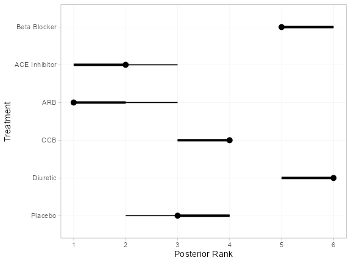

```r
plot(db_ranks)
```

```r
(db_rankprobs <- posterior_rank_probs(db_fit_RE))
```

```
#>                  p_rank[1] p_rank[2] p_rank[3] p_rank[4] p_rank[5] p_rank[6]
#> d[Beta Blocker]       0.00      0.00      0.00      0.01      0.79       0.2
#> d[ACE Inhibitor]      0.22      0.72      0.06      0.00      0.00       0.0
#> d[ARB]                0.77      0.20      0.03      0.00      0.00       0.0
#> d[CCB]                0.00      0.02      0.26      0.71      0.01       0.0
#> d[Diuretic]           0.00      0.00      0.00      0.00      0.20       0.8
#> d[Placebo]            0.01      0.06      0.66      0.27      0.01       0.0
```

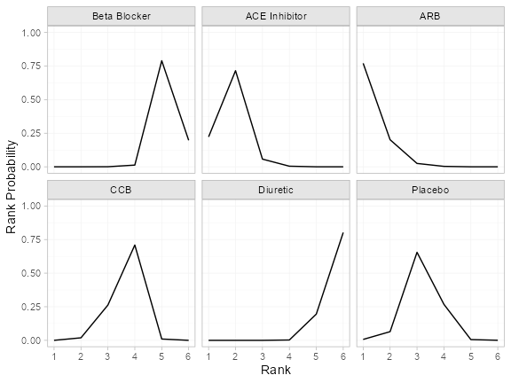

```r
plot(db_rankprobs)
```

```r
(db_cumrankprobs <- posterior_rank_probs(db_fit_RE, cumulative = TRUE))
```

```
#>                  p_rank[1] p_rank[2] p_rank[3] p_rank[4] p_rank[5] p_rank[6]
#> d[Beta Blocker]       0.00      0.00      0.00      0.01       0.8         1
#> d[ACE Inhibitor]      0.22      0.94      1.00      1.00       1.0         1
#> d[ARB]                0.77      0.97      1.00      1.00       1.0         1
#> d[CCB]                0.00      0.02      0.28      0.99       1.0         1
#> d[Diuretic]           0.00      0.00      0.00      0.00       0.2         1
#> d[Placebo]            0.01      0.07      0.73      0.99       1.0         1
```

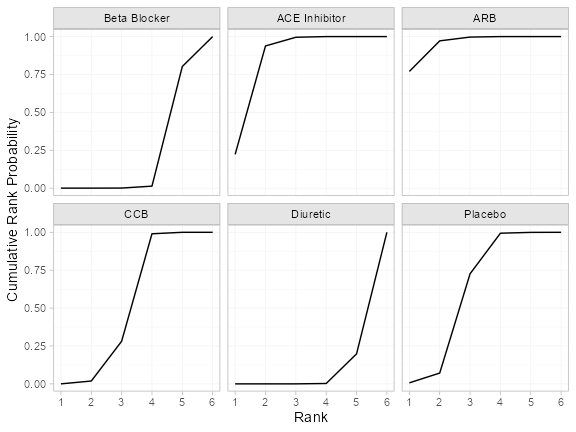

```r
plot(db_cumrankprobs)
```

## References

Dias, S., N. J. Welton, A. J. Sutton, and A. E. Ades. 2011. “NICE DSU Technical Support Document 2: A Generalised Linear Modelling Framework for Pair-Wise and Network Meta-Analysis of Randomised Controlled Trials.” National Institute for Health and Care Excellence. https://www.sheffield.ac.uk/nice-dsu.

Elliott, W. J., and P. M. Meyer. 2007. “Incident Diabetes in Clinical Trials of Antihypertensive Drugs: A Network Meta-Analysis.” *The Lancet* 369 (9557): 201–7. https://doi.org/10.1016/s0140-6736(07)60108-1.

[^1]: The gain in efficiency here from using “Beta Blocker” as the network reference treatment instead of “Diuretic” is considerable - around 4-8 times, in terms of effective samples per second. The functions in this package will always attempt to choose a default network reference treatment that maximises computational efficiency and stability. If you have chosen an alternative network reference treatment and the model runs very slowly or has low effective sample size, this is a likely cause.